# Human Activity Recognition (HAR): Weight Lifting Exercises (WLE) Classification

bdanalytics

#### Date: (Wed) Oct 29, 2014

Data: Measurement of exercises performed by six male participants aged between 20-28 years, with little weight lifting experience using a light dumbbell (1.25kg)  
Source: http://groupware.les.inf.puc-rio.br/har  
Time period: Nov - Dec 2011 (based on cvtd_timestamp values in data)

### Synopsis:

#### Model Summary: Random Forests:

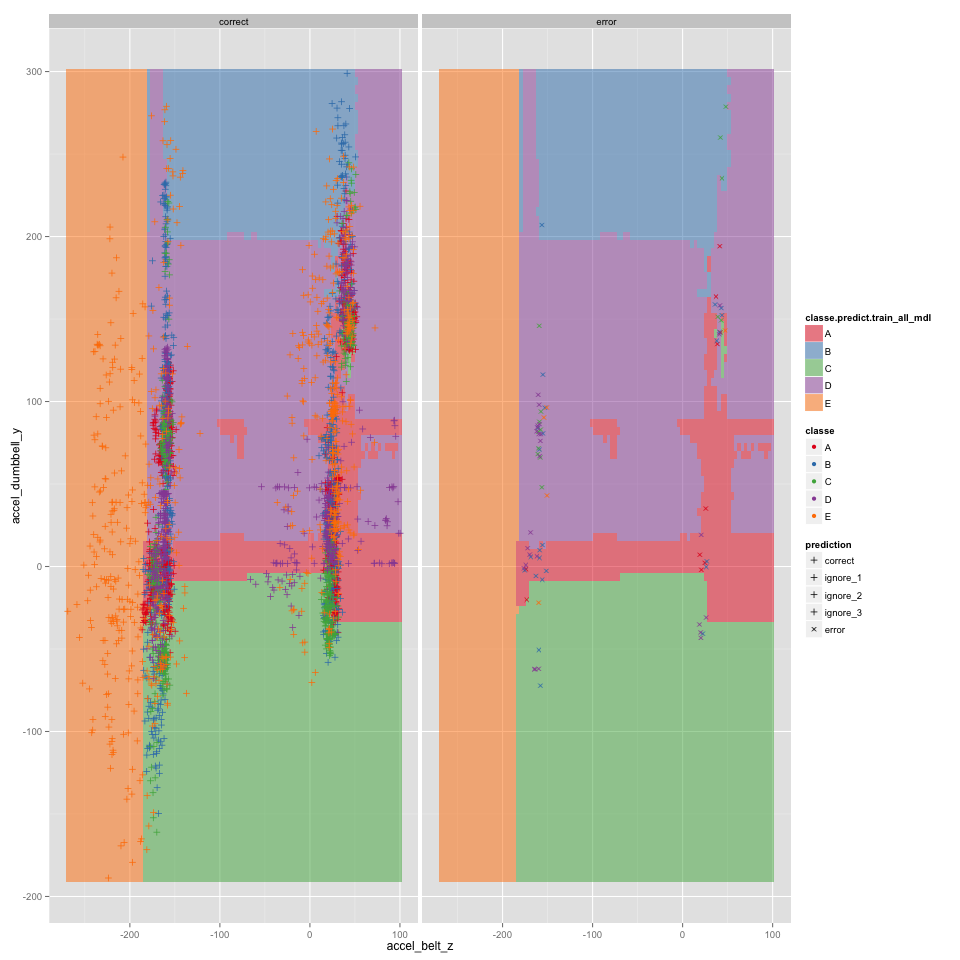

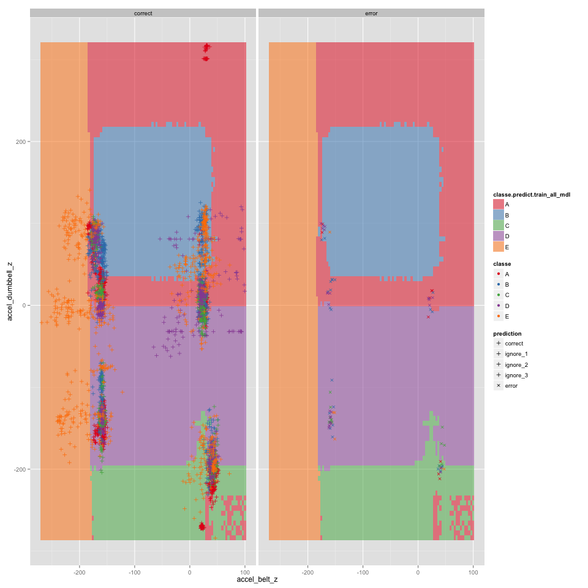

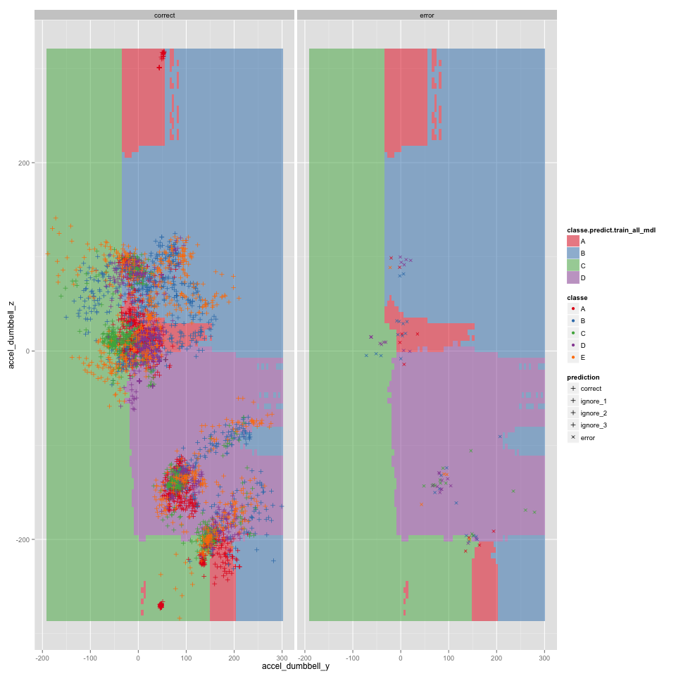

#### How you built your model:

1. Selected Random Forests (rf) since this is a multi-class classification problem & the associated research paper indicated that the original data collectors also utilized this algorithm.
2. Optimized fitting the model (first run on training data took a long time & did not complete):  
   2.1 Partitioned training data into training (64%), validation (16%) & testing (20%) data 2.2 Selected subset of training data - both rows & columns to fit “base” model within 30 elapsed seconds  
   2.3 Identified “base” model parameters such as pre-processing type, sampling method, number of resamples, mtry (rf tuning parameter) etc.  
   2.4 Generated a model parameter grid to vary parameters from the “base” model specifications  
   2.5 Fit one model for each row in the model parameter grid & collected elapsed time and prediction accuracy on the validation data set.  
   2.6 Optimized trade-off between elapsed time & validation data prediction accuracy to fit the “tuned” model within 60 elapsed seconds. This turned out to include only half the potential features and 20% of training data
3. Enhanced model to fit all training (incl. validation) data & tested prediction accuracy on testing data
4. Enhanced model to fit all training (incl. validation & testing) data & generated predictions on new data

#### How you used cross validation:

1. Utilized caret’s in-built sampling methods to select observations and features for each tree in the random forest
2. Sampled observations to optimize model fitting elapsed time vs. validation data prediction accuracy

#### Why you made the choices you did:

Explained classification algorithm selection earlier. Most of the effort went into optimizing the trade-offs between fitting time and prediction accuracy.

#### Use your prediction model to predict 20 different test cases:

Brief summary of the prediciton results on new data:

[output not shown]

#### Potential next steps include:

-1. Feature distribution checks 0. Add piece-wise glm logistic regression 1. Dummy Classifer 2. Compress analysis report (please feel free to stop here if you feel that the entire report is too detailed) 3. Peform PCA pre-processing and select “key” features to make the model more interpretable 4. Evaluate other classification algorithms (e.g. SVMs, kNN, etc.)

### Analysis:

```r
rm(list=ls())
set.seed(12345)
source("~/Dropbox/datascience/R/mydsutils.R")
source("~/Dropbox/datascience/R/myplot.R")
# Gather all package requirements here
suppressPackageStartupMessages(require(caret))
suppressPackageStartupMessages(require(plyr))
suppressPackageStartupMessages(require(reshape2))
suppressPackageStartupMessages(require(RColorBrewer))

script_df <- data.frame(chunk_label="import_data", chunk_step_major=1, chunk_step_minor=0)
```

#### Step `1`: import data

```r
entity_df <- myimport_data(
    "https://d396qusza40orc.cloudfront.net/predmachlearn/pml-training.csv",
    print_diagn=FALSE)
```

```
## [1] "Reading file ./data/pml-training.csv..."
## [1] "dimensions of data in ./data/pml-training.csv: 19,622 rows x 160 cols"
```

```r
predict_df <- myimport_data(
    "https://d396qusza40orc.cloudfront.net/predmachlearn/pml-testing.csv",
    print_diagn=FALSE)
```

```
## [1] "Reading file ./data/pml-testing.csv..."
## [1] "dimensions of data in ./data/pml-testing.csv: 20 rows x 160 cols"
```

```r
script_df <- rbind(script_df,
                   data.frame(chunk_label="inspect_data",
                              chunk_step_major=max(script_df$chunk_step_major)+1, chunk_step_minor=0))
```

#### Step `2`: inspect data

```r
#print(str(entity_df))
#print(str(predict_df))

# List info gathered for various columns
# X:                    int:    1:20            [record_id]
# user_name:            factor: 6 subject names

# raw_timestamp_part_1: int:                    [excluded for modeling]
# raw_timestamp_part_2: int:                    [excluded for modeling]
# cvtd_timestamp:       factor:                 [excluded for modeling]

# new_window:           factor: no; yes         [only no in predict_df]
# num_window:           int:    1:19622

# classe:               factor: 5 categories    [response variable]
# problem_id:           int:    1:20            [only in predict_df]

#print(summary(entity_df))
#print(summary(predict_df))
id_varnames <- c("user_name", "X")
response_varname <- "classe"
```

Many columns in new data (predict_df) are missing for all records. Let’s delete these columns from both training & new datasets to make the analysis faster & easier.

```r
all_na_cols <- myfind_all_na_cols_df(predict_df)
print("deleting all na cols:")
```

```
## [1] "deleting all na cols:"
```

```r
print(all_na_cols)
```

```
##   [1] "kurtosis_roll_belt"       "kurtosis_picth_belt"
##   [3] "kurtosis_yaw_belt"        "skewness_roll_belt"
##   [5] "skewness_roll_belt.1"     "skewness_yaw_belt"
##   [7] "max_roll_belt"            "max_picth_belt"
##   [9] "max_yaw_belt"             "min_roll_belt"
##  [11] "min_pitch_belt"           "min_yaw_belt"
##  [13] "amplitude_roll_belt"      "amplitude_pitch_belt"
##  [15] "amplitude_yaw_belt"       "var_total_accel_belt"
##  [17] "avg_roll_belt"            "stddev_roll_belt"
##  [19] "var_roll_belt"            "avg_pitch_belt"
##  [21] "stddev_pitch_belt"        "var_pitch_belt"
##  [23] "avg_yaw_belt"             "stddev_yaw_belt"
##  [25] "var_yaw_belt"             "var_accel_arm"
##  [27] "avg_roll_arm"             "stddev_roll_arm"
##  [29] "var_roll_arm"             "avg_pitch_arm"
```

[output cut: 35 more lines]

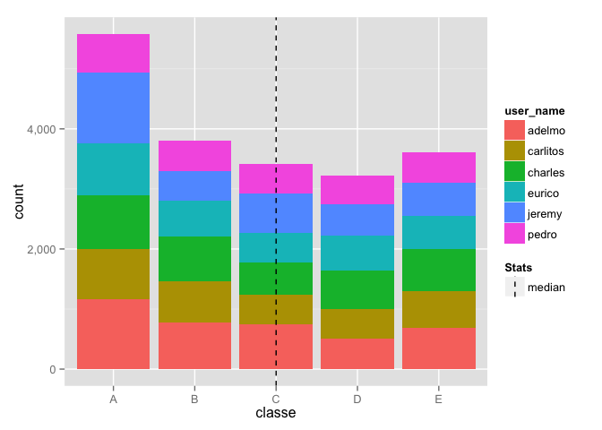

```r
predict_cln_df <- mydelete_cols_df(predict_df, all_na_cols)
#print(summary(predict_cln_df))

# get rid of the original datasets to save memory
predict_df <- predict_cln_df
entity_df <- mydelete_cols_df(entity_df, all_na_cols)
#print(summary(entity_df))

print(myplot_histogram(entity_df, "classe", fill_col_name="user_name"))
```

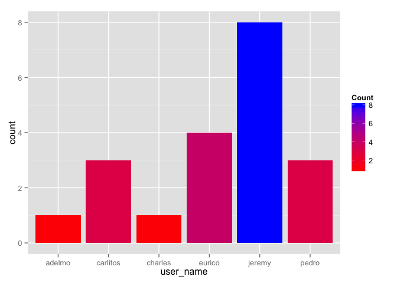

```r
print(myplot_histogram(predict_df, "user_name", show_stats=FALSE))
```

```r
script_df <- rbind(script_df,
                   data.frame(chunk_label="select_features",
                              chunk_step_major=max(script_df$chunk_step_major)+1, chunk_step_minor=0))
```

#### Step `3`: select features

````r
#```{r select_features_1}
features_lst <- names(predict_df)

# Remove features that are not relevant for modeling
features_lst <- features_lst[!(features_lst %in%
                                c(id_varnames, "problem_id"))]
features_lst <- features_lst[!(features_lst %in%
                                grep("timestamp", features_lst, value=TRUE))]

feats_df <- nearZeroVar(entity_df[, features_lst], saveMetrics=TRUE)
feats_df$feature <- rownames(feats_df)
# used later for plots
feats_df$percentUniqueCut_fctr <- cut(feats_df$percentUnique, breaks=5)
print(subset(feats_df, nzv == TRUE))
````

```
##            freqRatio percentUnique zeroVar  nzv    feature
## new_window  47.33005    0.01019264   FALSE TRUE new_window
##            percentUniqueCut_fctr
## new_window         (-0.074,16.8]
```

```r
nearZeroVars <- subset(feats_df, nzv == TRUE)$feature
print(summary(entity_df[, nearZeroVars]))
```

```
##    no   yes
## 19216   406
```

```r
print(summary(predict_df[, nearZeroVars]))
```

```
## no
## 20
```

```r
feats_df <- subset(feats_df, nzv == FALSE)
```

Let’s add a random variable (my.rnorm) as a feature since some models (e.g. random forests) like a random variable & any model that categorizes this feature as significant would be suspect.

```r
random_varname <- "my.rnorm"
predict_df$my.rnorm <- rnorm(nrow(predict_df))
entity_df$my.rnorm <- rnorm(nrow(entity_df))
feats_df[nrow(feats_df) + 1, "feature"] <- random_varname

# Since some steps might need to be re-run:
feats_save_df <- feats_df

script_df <- rbind(script_df,
                   data.frame(chunk_label="partition_data",
                              chunk_step_major=max(script_df$chunk_step_major)+1, chunk_step_minor=0))
```

#### Step `4`: partition data

````r
#```{r partition_data}

mypartition_data <- function(more_stratify_vars=NULL) {
    print(" "); print(sprintf("nrow(entity_df): %s", format(nrow(entity_df), big.mark=',')))
    if (missing(more_stratify_vars)) {
        print(table(entity_df[, response_varname]))
        keep_cols <- response_varname
    } else {
        entity_tbl <- table(entity_df[, response_varname],
                            entity_df[, more_stratify_vars])
        print(entity_tbl)
        keep_cols <- c(response_varname, more_stratify_vars)
    }

    inTrainValidate <- createDataPartition(y=entity_df[, response_varname],
                                           p=0.8, list=FALSE)
    train_validate_df <- entity_df[inTrainValidate, keep_cols]

    inTest <- setdiff(seq(1:nrow(entity_df)), inTrainValidate)
    inTest <- matrix(inTest, nrow=length(inTest),
                     dimnames=dimnames(inTrainValidate))
    test_df <- entity_df[inTest, keep_cols]

    inTrain <- createDataPartition(y=train_validate_df[, response_varname],
                                   p=0.8, list=FALSE)
    train_df <- train_validate_df[inTrain, keep_cols]

    inValidate <- setdiff(seq(1:nrow(train_validate_df)), inTrain)
    inValidate <- matrix(inValidate, nrow=length(inValidate),
                     dimnames=dimnames(inTrain))
    validate_df <- train_validate_df[inValidate, keep_cols]

    chk_nrow <- nrow(train_df) + nrow(validate_df) + nrow(test_df)
    if (nrow(entity_df) != chk_nrow)
        stop("entity_df not partitioned properly; nrow(entity_df): ",
             format(nrow(train_df), big.mark=','),
             " nrow of train+validate+test_df:",
             format(chk_nrow, big.mark=','))

    print(" "); print(sprintf("nrow(train_df): %s", format(nrow(train_df), big.mark=',')))
    print(suppressWarnings(formatC(table(train_df$classe,
        train_df[, more_stratify_vars]) / entity_tbl, digits=3, format='f')))

    print(" "); print(sprintf("nrow(validate_df): %s", format(nrow(validate_df), big.mark=',')))
    print(suppressWarnings(formatC(table(validate_df$classe,
        validate_df[, more_stratify_vars]) / entity_tbl, digits=3, format='f')))

    print(" "); print(sprintf("nrow(test_df): %s", format(nrow(test_df), big.mark=',')))
    print(suppressWarnings(formatC(table(test_df$classe,
        test_df[, more_stratify_vars]) / entity_tbl, digits=3, format='f')))

    return(list(inTrain=inTrain, inValidate=inValidate, inTest=inTest))
}
mypartition_data_lst <- mypartition_data(more_stratify_vars="user_name")
````

```
## [1] " "
## [1] "nrow(entity_df): 19,622"
##
##     adelmo carlitos charles eurico jeremy pedro
##   A   1165      834     899    865   1177   640
##   B    776      690     745    592    489   505
##   C    750      493     539    489    652   499
##   D    515      486     642    582    522   469
##   E    686      609     711    542    562   497
## [1] " "
## [1] "nrow(train_df): 12,562"
##
##     adelmo  carlitos charles eurico  jeremy  pedro
##   A "0.621" "0.633"  "0.648" "0.657" "0.642" "0.645"
##   B "0.616" "0.648"  "0.663" "0.642" "0.656" "0.616"
##   C "0.607" "0.686"  "0.625" "0.681" "0.627" "0.639"
##   D "0.633" "0.638"  "0.657" "0.607" "0.661" "0.646"
##   E "0.637" "0.655"  "0.660" "0.603" "0.651" "0.626"
## [1] " "
## [1] "nrow(validate_df): 3,137"
##
##     adelmo  carlitos charles eurico  jeremy  pedro
##   A "0.152" "0.157"  "0.157" "0.148" "0.169" "0.181"
##   B "0.189" "0.168"  "0.137" "0.150" "0.157" "0.150"
##   C "0.175" "0.128"  "0.161" "0.131" "0.183" "0.166"
##   D "0.184" "0.150"  "0.150" "0.184" "0.157" "0.130"
##   E "0.155" "0.158"  "0.173" "0.175" "0.130" "0.169"
## [1] " "
## [1] "nrow(test_df): 3,923"
##
##     adelmo  carlitos charles eurico  jeremy  pedro
##   A "0.227" "0.210"  "0.195" "0.195" "0.189" "0.173"
##   B "0.195" "0.184"  "0.200" "0.208" "0.186" "0.234"
##   C "0.219" "0.187"  "0.213" "0.188" "0.190" "0.194"
##   D "0.183" "0.212"  "0.193" "0.210" "0.182" "0.224"
##   E "0.208" "0.187"  "0.167" "0.221" "0.219" "0.205"
```

```r
keep_cols <- c(feats_df$feature, response_varname, id_varnames)
train_df <- entity_df[mypartition_data_lst$inTrain, keep_cols]
validate_df <- entity_df[mypartition_data_lst$inValidate, keep_cols]
test_df <- entity_df[mypartition_data_lst$inTest, keep_cols]

# all.equal(train_save_df, train_df)
# setdiff(union(names(train_save_df), names(train_df)), intersect(names(train_save_df), names(train_df)))

if (!("inspect_features" %in% script_df$chunk_label))
script_df <- rbind(script_df,
                   data.frame(chunk_label="inspect_features",
                              chunk_step_major=max(script_df$chunk_step_major)+1, chunk_step_minor=0))
```

#### Step `5`: inspect features

```r
# Compute feature correlations with response to prioritize feature selection for model design
feats_cor_df <- data.frame( response.cor=cor(train_df[, feats_df$feature],
                            unclass(train_df[, response_varname])))
feats_cor_df$response.cor.abs <- abs(feats_cor_df$response.cor)
feats_cor_df$feature <- rownames(feats_cor_df)
feats_cor_df <- orderBy(~ -response.cor.abs, data=feats_cor_df)

#intersect(names(feats_df), names(feats_cor_df))
feats_df <- feats_save_df
feats_tmp_df <- merge(feats_df, feats_cor_df)
feats_tmp_df <- orderBy(~ -response.cor.abs, data=feats_tmp_df)
#print(head(feats_tmp_df))
#print(head(feats_cor_df))

feats_all_df <- feats_tmp_df

# Extract features that have higher correlation than the random variable that was inducted ('my.rnorm')
feats_df <- subset(feats_all_df,
    response.cor.abs >= feats_all_df[which(feats_all_df$feature == random_varname),
                                    "response.cor.abs"])
feats_df <- orderBy(~ - response.cor.abs, feats_df)
myprint_df(feats_df)
```

```
##             feature freqRatio percentUnique zeroVar   nzv
## 42    pitch_forearm 65.983051     14.855774   FALSE FALSE
## 25     magnet_arm_x  1.000000      6.823973   FALSE FALSE
## 10  accel_forearm_x  1.126437      4.046478   FALSE FALSE
## 34 magnet_forearm_x  1.012346      7.766792   FALSE FALSE
## 1       accel_arm_x  1.017341      3.959841   FALSE FALSE
## 26     magnet_arm_y  1.056818      4.443991   FALSE FALSE
##    percentUniqueCut_fctr response.cor response.cor.abs
## 42         (-0.074,16.8]    0.4000952        0.4000952
## 25         (-0.074,16.8]    0.2990772        0.2990772
## 10         (-0.074,16.8]   -0.2783994        0.2783994
## 34         (-0.074,16.8]   -0.2742346        0.2742346
## 1          (-0.074,16.8]    0.2455778        0.2455778
## 26         (-0.074,16.8]   -0.2108394        0.2108394
##              feature freqRatio percentUnique zeroVar   nzv
```

[output cut: 27 more lines]

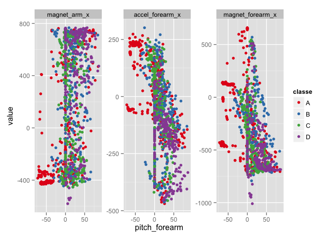

```r
# Plot subset of points since all points just creates a "waterfall" of the last color in the scale
train_plot_df <- melt(train_df[createDataPartition(y=train_df[, response_varname], p=0.1, list=FALSE),
                                c(response_varname, "user_name", feats_df$feature[1:4])],
                    measure.vars=c(feats_df$feature[2:4]))
#print(table(train_plot_df[, response_varname]))
print(ggplot(train_plot_df, aes_string(x=feats_df[1, "feature"],
                                        y="value",
                                  color=response_varname)) +
          geom_point(position="jitter") + scale_color_brewer(type="qual", palette="Set1") +
          facet_wrap(~ variable, scales="free_y"))
```

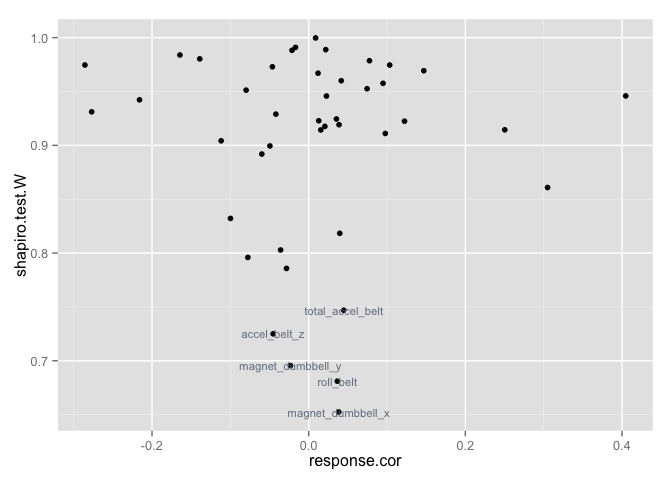

```r
# check feature distribution type
feats_df <- orderBy(~ - response.cor.abs, feats_df)
#feats_df[1, "shapiro.test.W"] <- shapiro.test(sample(train_df[, feats_df$feature[1]], size=5000))$statistic
feats_df$shapiro.test.W <- sapply(feats_df$feature,
    function(feat) shapiro.test(sample(train_df[, feat], size=5000))$statistic)

feats_plot_df <- mutate(feats_df,
                feature_label = ifelse((shapiro.test.W < 0.75), feature, ""))
print(ggplot(feats_plot_df, aes(x=response.cor, y=shapiro.test.W)) +
          geom_point(position="jitter") +
          geom_text(aes(label=feature_label), color="slategrey", size=3))
```

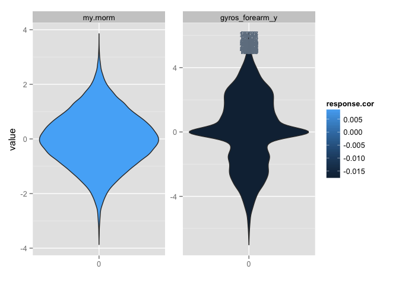

```r
# check distributions in entire data (incl. test) for outliers that might be
#   distorting the distributions
entity_plot_df <-
    melt(entity_df[, c(id_varnames, "my.rnorm",
                       "gyros_forearm_x", "gyros_forearm_y", "gyros_forearm_z")],
         id.vars=id_varnames)
entity_plot_df <- mutate(entity_plot_df,
    X_label = ifelse((  ((variable == "gyros_forearm_x") & (value < -5)) |
                        ((variable == "gyros_forearm_y") & (value >  5)) |
                        ((variable == "gyros_forearm_z") & (value >  5))),
                        X, ""))
entity_plot_df <- merge(entity_plot_df,
                        feats_df[, c("feature", "response.cor")],
                        by.x="variable", by.y="feature", all.y=FALSE)
print(ggplot(entity_plot_df, aes(x=factor(0), y=value)) +
          geom_violin(aes(fill=response.cor)) +
          geom_text(aes(label=X_label), color="slategrey", size=3) +
          facet_wrap(~ variable, scales="free_y") + xlab(""))
```

```r
myprint_df(feats_df)
```

```
##             feature freqRatio percentUnique zeroVar   nzv
## 42    pitch_forearm 65.983051     14.855774   FALSE FALSE
## 25     magnet_arm_x  1.000000      6.823973   FALSE FALSE
## 10  accel_forearm_x  1.126437      4.046478   FALSE FALSE
## 34 magnet_forearm_x  1.012346      7.766792   FALSE FALSE
## 1       accel_arm_x  1.017341      3.959841   FALSE FALSE
## 26     magnet_arm_y  1.056818      4.443991   FALSE FALSE
##    percentUniqueCut_fctr response.cor response.cor.abs shapiro.test.W
## 42         (-0.074,16.8]    0.4000952        0.4000952      0.9468980
## 25         (-0.074,16.8]    0.2990772        0.2990772      0.8621529
## 10         (-0.074,16.8]   -0.2783994        0.2783994      0.9760706
## 34         (-0.074,16.8]   -0.2742346        0.2742346      0.9283984
## 1          (-0.074,16.8]    0.2455778        0.2455778      0.9135746
## 26         (-0.074,16.8]   -0.2108394        0.2108394      0.9453705
##             feature freqRatio percentUnique zeroVar   nzv
```

[output cut: 27 more lines]

```r
print("Suspect data:")
```

```
## [1] "Suspect data:"
```

```r
print(entity_df[entity_df$X == 5373,])
```

```
##         X user_name raw_timestamp_part_1 raw_timestamp_part_2
## 5373 5373    eurico           1322489608               330677
##        cvtd_timestamp new_window num_window roll_belt pitch_belt yaw_belt
## 5373 28/11/2011 14:13         no        818      1.47       5.95    -87.4
##      total_accel_belt gyros_belt_x gyros_belt_y gyros_belt_z accel_belt_x
## 5373                3        -0.03            0        -0.05          -15
##      accel_belt_y accel_belt_z magnet_belt_x magnet_belt_y magnet_belt_z
## 5373            6           28            64           584          -424
##      roll_arm pitch_arm yaw_arm total_accel_arm gyros_arm_x gyros_arm_y
## 5373     79.1      44.2    82.6              29        0.59       -0.08
##      gyros_arm_z accel_arm_x accel_arm_y accel_arm_z magnet_arm_x
## 5373        0.03        -216         156         -87         -271
##      magnet_arm_y magnet_arm_z roll_dumbbell pitch_dumbbell yaw_dumbbell
## 5373          215          632      42.83528      -82.01759     57.16637
##      total_accel_dumbbell gyros_dumbbell_x gyros_dumbbell_y
## 5373                   58             -204               52
##      gyros_dumbbell_z accel_dumbbell_x accel_dumbbell_y accel_dumbbell_z
## 5373              317             -419              238              310
##      magnet_dumbbell_x magnet_dumbbell_y magnet_dumbbell_z roll_forearm
## 5373              -129               -66              69.6         0.48
##      pitch_forearm yaw_forearm total_accel_forearm gyros_forearm_x
## 5373         -0.14        0.34                 108             -22
##      gyros_forearm_y gyros_forearm_z accel_forearm_x accel_forearm_y
## 5373             311             231            -393             923
##      accel_forearm_z magnet_forearm_x magnet_forearm_y magnet_forearm_z
## 5373            -338                0           -0.123          -0.0917
##      classe   my.rnorm
## 5373      A -0.2402753
```

```r
# Make the suspect data missing & impute missing data & compare to original data
#   to verify that this might be a data entry error
entity_tmp_df <- entity_df
entity_tmp_df[entity_tmp_df$X == 5373,
              c("gyros_forearm_x", "gyros_forearm_y", "gyros_forearm_z")] <- NA
print(entity_tmp_df[entity_tmp_df$X == 5373, ])
```

```
##         X user_name raw_timestamp_part_1 raw_timestamp_part_2
## 5373 5373    eurico           1322489608               330677
##        cvtd_timestamp new_window num_window roll_belt pitch_belt yaw_belt
## 5373 28/11/2011 14:13         no        818      1.47       5.95    -87.4
##      total_accel_belt gyros_belt_x gyros_belt_y gyros_belt_z accel_belt_x
## 5373                3        -0.03            0        -0.05          -15
##      accel_belt_y accel_belt_z magnet_belt_x magnet_belt_y magnet_belt_z
## 5373            6           28            64           584          -424
##      roll_arm pitch_arm yaw_arm total_accel_arm gyros_arm_x gyros_arm_y
## 5373     79.1      44.2    82.6              29        0.59       -0.08
##      gyros_arm_z accel_arm_x accel_arm_y accel_arm_z magnet_arm_x
## 5373        0.03        -216         156         -87         -271
##      magnet_arm_y magnet_arm_z roll_dumbbell pitch_dumbbell yaw_dumbbell
## 5373          215          632      42.83528      -82.01759     57.16637
##      total_accel_dumbbell gyros_dumbbell_x gyros_dumbbell_y
## 5373                   58             -204               52
##      gyros_dumbbell_z accel_dumbbell_x accel_dumbbell_y accel_dumbbell_z
## 5373              317             -419              238              310
##      magnet_dumbbell_x magnet_dumbbell_y magnet_dumbbell_z roll_forearm
## 5373              -129               -66              69.6         0.48
##      pitch_forearm yaw_forearm total_accel_forearm gyros_forearm_x
## 5373         -0.14        0.34                 108              NA
##      gyros_forearm_y gyros_forearm_z accel_forearm_x accel_forearm_y
## 5373              NA              NA            -393             923
##      accel_forearm_z magnet_forearm_x magnet_forearm_y magnet_forearm_z
## 5373            -338                0           -0.123          -0.0917
##      classe   my.rnorm
## 5373      A -0.2402753
```

```r
preProc_lst <- preProcess(entity_tmp_df[, feats_df$feature], method=c("knnImpute"), verbose=TRUE)
```

```
## Calculating means for centering
## Calculating standard deviations for scaling
```

```r
print(preProc_lst)
```

```
##
## Call:
## preProcess.default(x = entity_tmp_df[, feats_df$feature], method
##  = c("knnImpute"), verbose = TRUE)
##
## Created from 19621 samples and 50 variables
## Pre-processing: 5 nearest neighbor imputation, scaled, centered
```

```r
entity_preProc_std_df <- data.frame(matrix(preProc_lst$std, nrow=1,
                                           ncol=length(preProc_lst$std),
                                           dimnames=list("std", names(preProc_lst$std))))
print(entity_preProc_std_df)
```

```
##     pitch_forearm magnet_arm_x magnet_belt_y magnet_arm_y accel_arm_x
## std      28.14553     443.6433      35.68086     201.9105    182.0449
##     accel_forearm_x pitch_arm magnet_belt_z magnet_forearm_x
## std        180.5937  30.68195      65.20955         346.9585
##     total_accel_forearm magnet_arm_z magnet_dumbbell_z total_accel_arm
## std            10.05596     326.6193          139.9638        10.52227
##     accel_dumbbell_x magnet_forearm_y accel_arm_y accel_belt_z roll_arm
## std         67.31676         509.3737     109.866     100.4467 72.74405
##     total_accel_belt pitch_dumbbell roll_belt magnet_dumbbell_x
## std         7.742309       36.99351  62.75026          339.7242
##     accel_dumbbell_z total_accel_dumbbell yaw_forearm roll_dumbbell
## std         109.4685             10.23344    103.2192      69.93172
##     accel_arm_z magnet_forearm_z  yaw_arm gyros_dumbbell_y num_window
## std    134.6529         369.2687 71.36338        0.6099903   247.9096
##     roll_forearm magnet_belt_x yaw_belt accel_forearm_y yaw_dumbbell
## std     108.0359      64.17929 95.19393        200.1301     82.51719
##     gyros_arm_y gyros_forearm_y accel_dumbbell_y gyros_arm_z
## std   0.8513906        2.165041         80.75064   0.5531688
##     gyros_forearm_x accel_belt_x gyros_forearm_z gyros_dumbbell_z
## std       0.6290476     29.64479       0.6017168         2.286599
##     gyros_dumbbell_x accel_forearm_z gyros_belt_z pitch_belt gyros_belt_x
## std         1.508553        138.3969    0.2413212   22.35124     0.207329
##      my.rnorm
## std 0.9943126
```

```r
entity_preProc_mean_df <- data.frame(matrix(preProc_lst$mean, nrow=1,
                                           ncol=length(preProc_lst$mean),
                                           dimnames=list("mean", names(preProc_lst$mean))))
print(entity_preProc_mean_df)
```

```
##      pitch_forearm magnet_arm_x magnet_belt_y magnet_arm_y accel_arm_x
## mean      10.70599      191.723       593.677     156.6113   -60.24019
##      accel_forearm_x pitch_arm magnet_belt_z magnet_forearm_x
## mean       -61.65182 -4.611925     -345.4808        -312.5759
##      total_accel_forearm magnet_arm_z magnet_dumbbell_z total_accel_arm
## mean            34.71532      306.491          46.05369        25.50856
##      accel_dumbbell_x magnet_forearm_y accel_arm_y accel_belt_z roll_arm
## mean        -28.61569         380.1164    32.59708    -72.59362 17.83018
##      total_accel_belt pitch_dumbbell roll_belt magnet_dumbbell_x
## mean         11.31261      -10.77942   64.4072         -328.4808
##      accel_dumbbell_z total_accel_dumbbell yaw_forearm roll_dumbbell
## mean        -38.32239             13.71838    19.20763      23.84151
##      accel_arm_z magnet_forearm_z    yaw_arm gyros_dumbbell_y num_window
## mean   -71.24508         393.6137 -0.6187514       0.04605647     430.64
##      roll_forearm magnet_belt_x  yaw_belt accel_forearm_y yaw_dumbbell
## mean     33.82654      55.60086 -11.20506        163.6559     1.674361
##      gyros_arm_y gyros_forearm_y accel_dumbbell_y gyros_arm_z
## mean  -0.2570808      0.05932827         52.63322   0.2694802
##      gyros_forearm_x accel_belt_x gyros_forearm_z gyros_dumbbell_z
## mean       0.1590806     -5.59469       0.1394796       -0.1289889
##      gyros_dumbbell_x accel_forearm_z gyros_belt_z pitch_belt gyros_belt_x
## mean        0.1610845       -55.29192   -0.1305377  0.3052828 -0.005592192
##          my.rnorm
## mean -0.002801637
```

```r
# entity_preProc_df <- data.frame(preProc_lst$data)
# all.equal(entity_preProc_df, entity_tmp_df[, feats_df$feature])
require(RANN)
entity_preProc_df <- predict(preProc_lst, entity_tmp_df[, feats_df$feature], verbose=TRUE)
entity_invProc_df <- entity_preProc_df
# entity_invProc_df[, "accel_arm_x"] <- (entity_preProc_df[, "accel_arm_x"] *
#                                     entity_preProc_std_df[1, "accel_arm_x"]) +
#                                     entity_preProc_mean_df[1, "accel_arm_x"]
for (feat in feats_df$feature)
    entity_invProc_df[, feat] <- (entity_preProc_df[, feat] *
                                entity_preProc_std_df[1, feat]) +
                                entity_preProc_mean_df[1, feat]
entity_invProc_df[, id_varnames] <- entity_df[, id_varnames]
#all.equal(entity_invProc_df[, "accel_arm_x"], entity_tmp_df[, "accel_arm_x"])
print(all.equal(entity_invProc_df[, feats_df$feature],
          entity_tmp_df[, feats_df$feature]))
```

```
## [1] "Component \"gyros_forearm_y\": 'is.NA' value mismatch: 1 in current 0 in target"
## [2] "Component \"gyros_forearm_x\": 'is.NA' value mismatch: 1 in current 0 in target"
## [3] "Component \"gyros_forearm_z\": 'is.NA' value mismatch: 1 in current 0 in target"
```

```r
print(entity_df[entity_df$X == 5373,
                    c("gyros_forearm_x", "gyros_forearm_y", "gyros_forearm_z")])
```

```
##      gyros_forearm_x gyros_forearm_y gyros_forearm_z
## 5373             -22             311             231
```

```r
print(entity_tmp_df[entity_tmp_df$X == 5373,
                    c("gyros_forearm_x", "gyros_forearm_y", "gyros_forearm_z")])
```

```
##      gyros_forearm_x gyros_forearm_y gyros_forearm_z
## 5373              NA              NA              NA
```

```r
print(entity_invProc_df[entity_invProc_df$X == 5373,
                    c("gyros_forearm_x", "gyros_forearm_y", "gyros_forearm_z")])
```

```
##      gyros_forearm_x gyros_forearm_y gyros_forearm_z
## 5373           0.512           1.276           0.642
```

It appears that this observation has some data entry errors. Since it’s just 1 observation, let’s delete this. If there were more occurences of these errors, we can then consider including the imputed data.

```r
print(sprintf("Rows before deletion: %s", format(nrow(entity_df), big.mark=',')))
```

```
## [1] "Rows before deletion: 19,622"
```

```r
entity_df <- entity_df[entity_df$X != 5373, ]
print(sprintf("Rows after  deletion: %s", format(nrow(entity_df), big.mark=',')))
```

```
## [1] "Rows after  deletion: 19,621"
```

Now, we need to re-run a whole bunch of stuff.  
#### Step `4`: partition data: run 2

```r
mypartition_data_lst <- mypartition_data(more_stratify_vars="user_name")
```

```
## [1] " "
## [1] "nrow(entity_df): 19,621"
##
##     adelmo carlitos charles eurico jeremy pedro
##   A   1165      834     899    864   1177   640
##   B    776      690     745    592    489   505
##   C    750      493     539    489    652   499
##   D    515      486     642    582    522   469
##   E    686      609     711    542    562   497
## [1] " "
## [1] "nrow(train_df): 12,562"
##
##     adelmo  carlitos charles eurico  jeremy  pedro
##   A "0.658" "0.643"  "0.643" "0.645" "0.630" "0.614"
##   B "0.639" "0.612"  "0.671" "0.627" "0.624" "0.667"
##   C "0.613" "0.649"  "0.677" "0.628" "0.632" "0.655"
##   D "0.672" "0.683"  "0.628" "0.622" "0.615" "0.629"
##   E "0.647" "0.614"  "0.617" "0.640" "0.644" "0.690"
## [1] " "
## [1] "nrow(validate_df): 3,137"
##
##     adelmo  carlitos charles eurico  jeremy  pedro
##   A "0.147" "0.152"  "0.168" "0.152" "0.167" "0.180"
##   B "0.160" "0.165"  "0.142" "0.177" "0.182" "0.137"
##   C "0.167" "0.150"  "0.141" "0.170" "0.155" "0.176"
##   D "0.136" "0.148"  "0.170" "0.158" "0.184" "0.160"
##   E "0.149" "0.174"  "0.170" "0.166" "0.155" "0.143"
## [1] " "
## [1] "nrow(test_df): 3,922"
##
##     adelmo  carlitos charles eurico  jeremy  pedro
##   A "0.196" "0.205"  "0.189" "0.204" "0.202" "0.206"
##   B "0.201" "0.223"  "0.187" "0.196" "0.194" "0.196"
##   C "0.220" "0.201"  "0.182" "0.202" "0.213" "0.168"
##   D "0.192" "0.169"  "0.202" "0.220" "0.201" "0.211"
##   E "0.204" "0.212"  "0.212" "0.194" "0.201" "0.167"
```

```r
keep_cols <- c(feats_df$feature, response_varname, id_varnames)
train_df <- entity_df[mypartition_data_lst$inTrain, keep_cols]
validate_df <- entity_df[mypartition_data_lst$inValidate, keep_cols]
test_df <- entity_df[mypartition_data_lst$inTest, keep_cols]
```

#### Step `5`: inspect features: run 2

```r
# Compute feature correlations with response to prioritize feature selection for model design
feats_cor_df <- data.frame( response.cor=cor(train_df[, feats_df$feature],
                            unclass(train_df[, response_varname])))
feats_cor_df$response.cor.abs <- abs(feats_cor_df$response.cor)
feats_cor_df$feature <- rownames(feats_cor_df)
feats_cor_df <- orderBy(~ -response.cor.abs, data=feats_cor_df)

#intersect(names(feats_df), names(feats_cor_df))
feats_df <- feats_save_df
feats_tmp_df <- merge(feats_df, feats_cor_df)
feats_tmp_df <- orderBy(~ -response.cor.abs, data=feats_tmp_df)
#print(head(feats_tmp_df))
#print(head(feats_cor_df))

feats_all_df <- feats_tmp_df

# Extract features that have higher correlation than the random variable that was inducted ('my.rnorm')
feats_df <- subset(feats_all_df,
    response.cor.abs >= feats_all_df[which(feats_all_df$feature == random_varname),
                                    "response.cor.abs"])
feats_df <- orderBy(~ - response.cor.abs, feats_df)
myprint_df(feats_df)
```

```
##             feature freqRatio percentUnique zeroVar   nzv
## 37    pitch_forearm 65.983051     14.855774   FALSE FALSE
## 21     magnet_arm_x  1.000000      6.823973   FALSE FALSE
## 9   accel_forearm_x  1.126437      4.046478   FALSE FALSE
## 30 magnet_forearm_x  1.012346      7.766792   FALSE FALSE
## 1       accel_arm_x  1.017341      3.959841   FALSE FALSE
## 22     magnet_arm_y  1.056818      4.443991   FALSE FALSE
##    percentUniqueCut_fctr response.cor response.cor.abs
## 37         (-0.074,16.8]    0.4045898        0.4045898
## 21         (-0.074,16.8]    0.3050338        0.3050338
## 9          (-0.074,16.8]   -0.2854523        0.2854523
## 30         (-0.074,16.8]   -0.2769695        0.2769695
## 1          (-0.074,16.8]    0.2503397        0.2503397
## 22         (-0.074,16.8]   -0.2160270        0.2160270
##                 feature freqRatio percentUnique zeroVar   nzv
```

[output cut: 27 more lines]

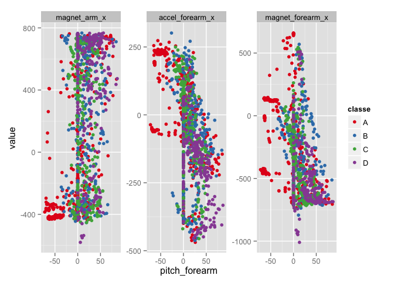

```r
# Plot subset of points since all points just creates a "waterfall" of the last color in the scale
train_plot_df <- melt(train_df[createDataPartition(y=train_df[, response_varname], p=0.1, list=FALSE),
                                c(response_varname, "user_name", feats_df$feature[1:4])],
                    measure.vars=c(feats_df$feature[2:4]))
#print(table(train_plot_df[, response_varname]))
print(ggplot(train_plot_df, aes_string(x=feats_df[1, "feature"],
                                        y="value",
                                  color=response_varname)) +
          geom_point(position="jitter") + scale_color_brewer(type="qual", palette="Set1") +
          facet_wrap(~ variable, scales="free_y"))
```

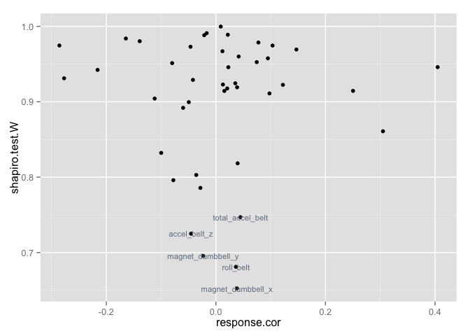

```r
# check feature distribution type
feats_df <- orderBy(~ - response.cor.abs, feats_df)
#feats_df[1, "shapiro.test.W"] <- shapiro.test(sample(train_df[, feats_df$feature[1]], size=5000))$statistic
feats_df$shapiro.test.W <- sapply(feats_df$feature,
    function(feat) shapiro.test(sample(train_df[, feat], size=5000))$statistic)

feats_plot_df <- mutate(feats_df,
                feature_label = ifelse((shapiro.test.W < 0.75), feature, ""))
print(ggplot(feats_plot_df, aes(x=response.cor, y=shapiro.test.W)) +
          geom_point(position="jitter") +
          geom_text(aes(label=feature_label), color="slategrey", size=3))
```

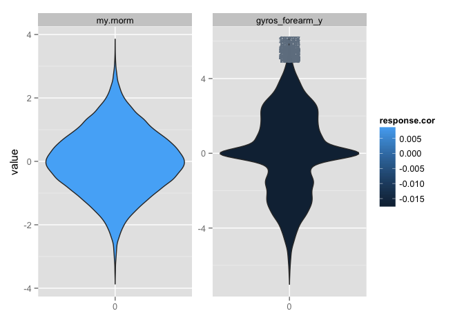

```r
# check distributions in entire data (incl. test) for outliers that might be
#   distorting the distributions
entity_plot_df <-
    melt(entity_df[, c(id_varnames, "my.rnorm",
                       "gyros_forearm_x", "gyros_forearm_y", "gyros_forearm_z")],
         id.vars=id_varnames)
entity_plot_df <- mutate(entity_plot_df,
    X_label = ifelse((  ((variable == "gyros_forearm_x") & (value < -5)) |
                        ((variable == "gyros_forearm_y") & (value >  5)) |
                        ((variable == "gyros_forearm_z") & (value >  5))),
                        X, ""))
entity_plot_df <- merge(entity_plot_df,
                        feats_df[, c("feature", "response.cor")],
                        by.x="variable", by.y="feature", all.y=FALSE)
print(ggplot(entity_plot_df, aes(x=factor(0), y=value)) +
          geom_violin(aes(fill=response.cor)) +
          geom_text(aes(label=X_label), color="slategrey", size=3) +
          facet_wrap(~ variable, scales="free_y") + xlab(""))
```

```r
myprint_df(feats_df)
```

```
##             feature freqRatio percentUnique zeroVar   nzv
## 37    pitch_forearm 65.983051     14.855774   FALSE FALSE
## 21     magnet_arm_x  1.000000      6.823973   FALSE FALSE
## 9   accel_forearm_x  1.126437      4.046478   FALSE FALSE
## 30 magnet_forearm_x  1.012346      7.766792   FALSE FALSE
## 1       accel_arm_x  1.017341      3.959841   FALSE FALSE
## 22     magnet_arm_y  1.056818      4.443991   FALSE FALSE
##    percentUniqueCut_fctr response.cor response.cor.abs shapiro.test.W
## 37         (-0.074,16.8]    0.4045898        0.4045898      0.9459192
## 21         (-0.074,16.8]    0.3050338        0.3050338      0.8608725
## 9          (-0.074,16.8]   -0.2854523        0.2854523      0.9745998
## 30         (-0.074,16.8]   -0.2769695        0.2769695      0.9311625
## 1          (-0.074,16.8]    0.2503397        0.2503397      0.9144510
## 22         (-0.074,16.8]   -0.2160270        0.2160270      0.9422727
##             feature freqRatio percentUnique zeroVar   nzv
```

[output cut: 27 more lines]

```r
script_df <- rbind(script_df,
                   data.frame(chunk_label="design_models",
                              chunk_step_major=max(script_df$chunk_step_major)+1, chunk_step_minor=0))
```

#### Step `6`: design models

```r
# Create a function to fit a model based on different tuning parameters which will be used to optimize fit elapsed time vs. validation data prediction accuracy
mytrain_model <- function(par_row, fit_df=train_df) {
    #print(sprintf("num_feats: %d", num_feats))
    #print(sprintf("p_obs: %f", par_row$p_obs))

    # Because of random forests, let's try to make each fit run as similar as possible
    set.seed(12345)

    mdl_frmla <- reformulate(feats_df$feature[1:par_row$num_feats], response_varname)
    train_sst_df <- fit_df[createDataPartition(y=fit_df[, response_varname],
                                                 p=par_row$p_obs, list=FALSE),
                             c(response_varname, feats_df$feature[1:par_row$num_feats])]
    ctrl <- trainControl(method=par_row$sampling_method
                        , number=par_row$n_resample
                        #, repeats=repeats
                        #, seeds = seeds
                        )

    # mtry is a tuning parameter for random forests
    if (par_row$mtry > -1) tune_grid <- expand.grid(mtry=par_row$mtry)
    else tune_grid <- NULL;

    mdl <- train(mdl_frmla, data=train_sst_df,
                preProcess=eval(parse(text=par_row$preProcess)),
                method="rf", tuneGrid=tune_grid
                , trControl = ctrl
                )
    #print(mdl)
    #print(varImp(mdl))

    # collect fitting results data
    df <- data.frame(
                    num_feats=par_row$num_feats,
                    p_obs=par_row$p_obs,
                    preProcess=par_row$preProcess,
                    sampling_method=par_row$sampling_method,
                    n_resample=nrow(mdl$resample),
                    mtry=mdl$results[nrow(mdl$results), "mtry"],
                    accuracy_train=mdl$results[nrow(mdl$results), "Accuracy"],
                    accuracy_valdt=sum((validate_df$classe ==
                                        predict(mdl, newdata=validate_df)) * 1) /
                                    nrow(validate_df),
                    elapsed=mdl$times$everything["elapsed"])
    rownames(df) <- par_row$mdl_name

    # this took a long time to figure out. model object from caret package cannot
    #   be coerced into the return data frame. Please feel free to suggest a
    #   beter method to handle multiple return objects
    return(list(fit_mdl=mdl, fit_df=df))
}

# Run this process several times to
#   maximize feature selection,
#   maximize utilization of all training data observations
#   maximize accuracy of predictions on validation data
#   minimize elapsed time of fitting
#   The constraints at this step:
#       elapsed time < 60 secs

par_grid <- data.frame(mdl_name='base', num_feats=nrow(feats_df) / 2, p_obs=0.20,
                       preProcess='NULL', sampling_method="cv", n_resample=10,
                       mtry=3, stringsAsFactors=FALSE)
par_grid[2:7, ] <- par_grid[1, ]

par_grid[2, "mdl_name"] <- "num_feats=all";         par_grid[2, "num_feats"] <- nrow(feats_df)
par_grid[3, "mdl_name"] <- "p_obs=0.30";            par_grid[3, "p_obs"] <- 0.30
par_grid[4, "mdl_name"] <- "preProcess=center;scl"; par_grid[4, "preProcess"] <- 'c("center", "scale")'
par_grid[5, "mdl_name"] <- "sampling_method=boot";  par_grid[5, "sampling_method"] <- 'boot'
par_grid[6, "mdl_name"] <- "n_resample=15";         par_grid[6, "n_resample"] <- 15
par_grid[7, "mdl_name"] <- "mtry=6";                par_grid[7, "mtry"] <- 6

#par_grid[2:7, "n_resample"] <- 10
#par_grid[2:7, "sampling_method"] <- 'cv'
print(par_grid)
```

```
##                mdl_name num_feats p_obs           preProcess
## 1                  base        25   0.2                 NULL
## 2         num_feats=all        50   0.2                 NULL
## 3            p_obs=0.30        25   0.3                 NULL
## 4 preProcess=center;scl        25   0.2 c("center", "scale")
## 5  sampling_method=boot        25   0.2                 NULL
## 6         n_resample=15        25   0.2                 NULL
## 7                mtry=6        25   0.2                 NULL
##   sampling_method n_resample mtry
## 1              cv         10    3
## 2              cv         10    3
## 3              cv         10    3
## 4              cv         10    3
## 5            boot         10    3
## 6              cv         15    3
## 7              cv         10    6
```

```r
models_df <- data.frame()
for (row in 1:nrow(par_grid)) {
    print(sprintf("fitting model for row: %d", row))
    attach(mytrain_model(par_grid[row, ]))
    mdl <- fit_mdl; head(predict(mdl, newdata=validate_df)); #print(mdl)
    models_df <- rbind(models_df, fit_df); #print(models_df)
    if (row == 1) mdl_1 <- mdl
    if (row == 2) mdl_2 <- mdl
    if (row == 3) mdl_3 <- mdl
    if (row == 4) mdl_4 <- mdl
    if (row == 5) mdl_5 <- mdl
    if (row == 6) mdl_6 <- mdl
    if (row == 7) mdl_7 <- mdl
    detach(grep("^mytrain_model", search(), value=TRUE), character.only=TRUE)
}
```

```
## [1] "fitting model for row: 1"
## [1] "fitting model for row: 2"
## [1] "fitting model for row: 3"
## [1] "fitting model for row: 4"
## [1] "fitting model for row: 5"
## [1] "fitting model for row: 6"
## [1] "fitting model for row: 7"
```

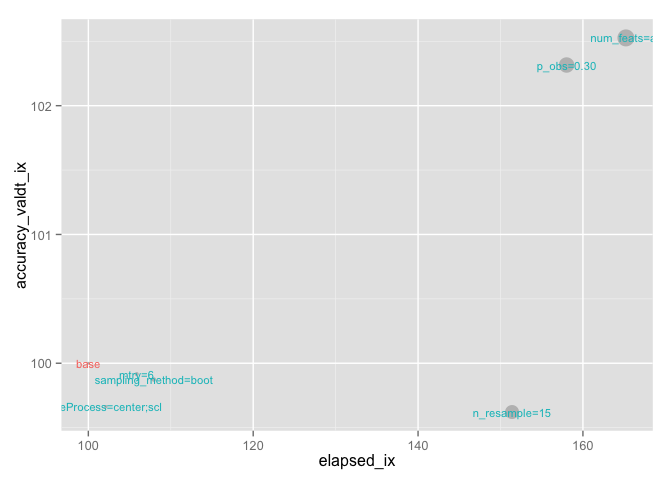

````r
#```{r design_models_2}
models_df$id <- rownames(models_df)
models_df$accuracy_valdt_ix <- models_df$accuracy_valdt * 100.0 / models_df$accuracy_valdt[1]
models_df$elapsed_ix <- models_df$elapsed * 100.0 / models_df$elapsed[1]
models_df <- mutate(models_df, color=ifelse((id == "base"), "black", "NavyBlue"))
#print(orderBy(~ - elapsed_ix + accuracy_valdt_ix, data=models_df))
# print(myplot_scatter(models_df, "elapsed_ix", "accuracy_valdt_ix") +
#         geom_text(aes(label=id, color=color), size=3) +
#         theme(legend.position="none"))
print(ggplot(models_df, aes(x=elapsed_ix, y=accuracy_valdt_ix)) +
        geom_point(aes(size=elapsed), color="grey") +
        geom_text(aes(label=id, color=color), size=3) +
        theme(legend.position="none"))
````

```r
sel_mdl <- mdl_1
print(sel_mdl)
```

```
## Random Forest
##
## 2515 samples
##   25 predictor
##    5 classes: 'A', 'B', 'C', 'D', 'E'
##
## No pre-processing
## Resampling: Cross-Validated (10 fold)
##
## Summary of sample sizes: 2264, 2265, 2264, 2265, 2264, 2261, ...
##
## Resampling results
##
##   Accuracy  Kappa  Accuracy SD  Kappa SD
##   0.931     0.912  0.0212       0.0269
##
## Tuning parameter 'mtry' was held constant at a value of 3
##
```

```r
print(sel_mdl$finalModel)
```

```
##
## Call:
##  randomForest(x = x, y = y, mtry = param$mtry)
##                Type of random forest: classification
##                      Number of trees: 500
## No. of variables tried at each split: 3
##
##         OOB estimate of  error rate: 6.96%
## Confusion matrix:
##     A   B   C   D   E class.error
## A 700   4   7   4   0  0.02097902
## B  29 433  22   1   2  0.11088296
## C   3  19 402  12   3  0.08428246
## D   3   0  25 379   5  0.08009709
## E   1  18   9   8 426  0.07792208
```

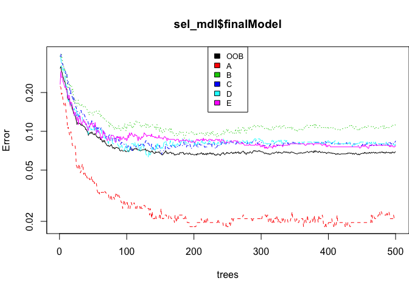

```r
par(mar=c(5,4,4,0)) #No margin on the right side
plot(sel_mdl$finalModel, log="y")
par(mar=c(5,0,4,2)) #No margin on the left side
#plot(c(0,1),type="n", axes=F, xlab="", ylab="")    # not sure what this does
# the 6 in this code refers to unique(response_varname) + 1 (for OutOfBag)
legend("top", colnames(sel_mdl$finalModel$err.rate),col=1:6,cex=0.8,fill=1:6)
```

```r
confMatrix_sel_mdl <- confusionMatrix(validate_df[, response_varname],
                                        predict(sel_mdl, newdata=validate_df))
print(confMatrix_sel_mdl)
```

```
## Confusion Matrix and Statistics
##
##           Reference
## Prediction   A   B   C   D   E
##          A 700  10   3   4   0
##          B  15 433  18   5   1
##          C   2  13 396   7   0
##          D   4   1  26 411   1
##          E   1   9  11   7 435
##
## Overall Statistics
##
##                Accuracy : 0.9451
##                  95% CI : (0.9354, 0.9537)
##     No Information Rate : 0.2873
##     P-Value [Acc > NIR] : < 2.2e-16
##
##                   Kappa : 0.9305
##  Mcnemar's Test P-Value : 3.089e-05
##
## Statistics by Class:
##
##                      Class: A Class: B Class: C Class: D Class: E
## Sensitivity            0.9695   0.9292   0.8722   0.9470   0.9954
## Specificity            0.9905   0.9809   0.9893   0.9846   0.9865
## Pos Pred Value         0.9763   0.9174   0.9474   0.9278   0.9395
## Neg Pred Value         0.9878   0.9838   0.9723   0.9889   0.9990
## Prevalence             0.2873   0.1854   0.1807   0.1727   0.1739
## Detection Rate         0.2786   0.1723   0.1576   0.1635   0.1731
## Detection Prevalence   0.2853   0.1878   0.1663   0.1763   0.1842
## Balanced Accuracy      0.9800   0.9551   0.9308   0.9658   0.9910
```

```r
#print(varImp(sel_mdl))
```

```r
mymerge_varimp <- function(f_df, mdl, mdl_name) {
    varimp_df <- varImp(mdl)$importance
    varimp_varname <- c(paste0(mdl_name, ".Importance"))
    names(varimp_df) <- varimp_varname
    varimp_df$feature <- rownames(varimp_df)
    intersect(names(varimp_df), names(f_df))

    f_df <- merge(f_df, varimp_df, all.x=TRUE)
    print(ggplot(f_df, aes_string(x="response.cor", y=varimp_varname)) +
            geom_point(aes_string(size="freqRatio", shape="percentUniqueCut_fctr"),
                       color="grey") +
            geom_text(aes_string(label="feature"), size=3.5, color="blue"))
    return(f_df)
}
print(names(feats_df))
```

```
## [1] "feature"               "freqRatio"             "percentUnique"
## [4] "zeroVar"               "nzv"                   "percentUniqueCut_fctr"
## [7] "response.cor"          "response.cor.abs"
```

```r
feats_df <- mymerge_varimp(feats_df, sel_mdl, "sel_mdl")
```

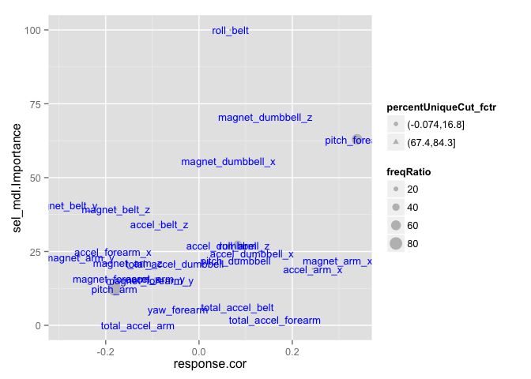

```r
feats_tmp_df <- orderBy(~ -response.cor.abs + sel_mdl.Importance, data=feats_df)

script_df <- rbind(script_df,
                   data.frame(chunk_label="fit_all_train",
                              chunk_step_major=max(script_df$chunk_step_major)+1, chunk_step_minor=0))
```

#### Step `7`: fit all training obs

```r
par_row <- par_grid[1, ]; par_row$mdl_name <- 'train_all'; par_row$p_obs <- 1.0;
#par_row$mtry <- -1  # allow caret to optimize
print(par_row)
```

```
##    mdl_name num_feats p_obs preProcess sampling_method n_resample mtry
## 1 train_all        25     1       NULL              cv         10    3
```

```r
attach(mytrain_model(par_row, fit_df=rbind(train_df, validate_df)))
train_all_mdl <- fit_mdl;
detach(grep("^mytrain_model", search(), value=TRUE), character.only=TRUE)

print(train_all_mdl)
```

```
## Random Forest
##
## 15070 samples
##    25 predictor
##     5 classes: 'A', 'B', 'C', 'D', 'E'
##
## No pre-processing
## Resampling: Cross-Validated (10 fold)
##
## Summary of sample sizes: 13563, 13564, 13563, 13563, 13562, 13564, ...
##
## Resampling results
##
##   Accuracy  Kappa  Accuracy SD  Kappa SD
##   0.983     0.978  0.00346      0.00438
##
## Tuning parameter 'mtry' was held constant at a value of 3
##
```

```r
print(train_all_mdl$finalModel)
```

```
##
## Call:
##  randomForest(x = x, y = y, mtry = param$mtry)
##                Type of random forest: classification
##                      Number of trees: 500
## No. of variables tried at each split: 3
##
##         OOB estimate of  error rate: 1.55%
## Confusion matrix:
##      A    B    C    D    E class.error
## A 4250    7   10   20    1 0.008861940
## B   30 2837   28    4    3 0.022398346
## C    5   21 2570   12    0 0.014570552
## D   14    2   44 2432    9 0.027588964
## E    6    1   10    7 2747 0.008661133
```

```r
#print(varImp(train_all_mdl))
feats_df <- mymerge_varimp(feats_df, train_all_mdl, "train_all_mdl")
```

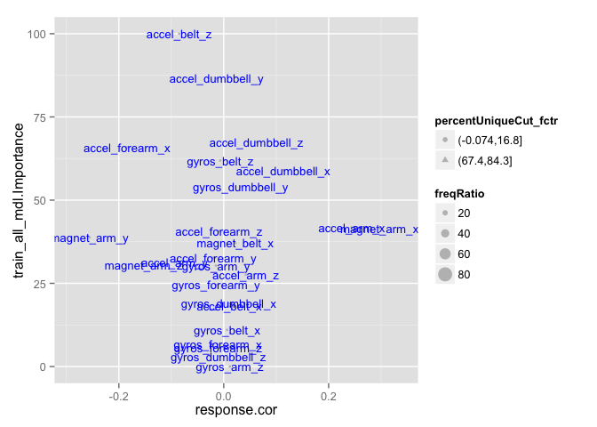

```r
# script_df <- rbind(script_df,
#                    data.frame(chunk_label="fit_all_obs",
#                               chunk_step_major=max(script_df$chunk_step_major)+1, chunk_step_minor=0))
```

````r
#```{r inspect_test_predictions_1}
response_predict_varname <- paste0(response_varname, ".predict.", "train_all_mdl")
response_error_varname <- paste0(response_varname, ".error.", "train_all_mdl")
test_df[, response_predict_varname] <- predict(train_all_mdl, test_df)
test_df[, response_error_varname] <-
    factor((test_df[, response_varname] != test_df[, response_predict_varname]) * 1,
              labels=c("correct", "error"))
print(head(test_df[, c("user_name", response_varname,
                       response_predict_varname, response_error_varname)]))
````

```
##    user_name classe classe.predict.train_all_mdl
## 4   carlitos      A                            A
## 7   carlitos      A                            A
## 9   carlitos      A                            A
## 35  carlitos      A                            A
## 39  carlitos      A                            A
## 41  carlitos      A                            A
##    classe.error.train_all_mdl
## 4                     correct
## 7                     correct
## 9                     correct
## 35                    correct
## 39                    correct
## 41                    correct
```

```r
confMatrix_train_all_mdl <- confusionMatrix(test_df[, response_varname],
                                            test_df[, response_predict_varname])
print(confMatrix_train_all_mdl)
```

```
## Confusion Matrix and Statistics
##
##           Reference
## Prediction    A    B    C    D    E
##          A 1106    1    4    5    0
##          B   12  735   11    0    1
##          C    4    4  670    6    0
##          D    4    0   21  617    1
##          E    1    0    1    3  716
##
## Overall Statistics
##
##                Accuracy : 0.9799
##                  95% CI : (0.975, 0.984)
##     No Information Rate : 0.2873
##     P-Value [Acc > NIR] : < 2.2e-16
##
##                   Kappa : 0.9745
##  Mcnemar's Test P-Value : NA
##
## Statistics by Class:
##
##                      Class: A Class: B Class: C Class: D Class: E
## Sensitivity            0.9814   0.9932   0.9477   0.9778   0.9972
## Specificity            0.9964   0.9925   0.9956   0.9921   0.9984
## Pos Pred Value         0.9910   0.9684   0.9795   0.9596   0.9931
## Neg Pred Value         0.9925   0.9984   0.9886   0.9957   0.9994
## Prevalence             0.2873   0.1886   0.1802   0.1608   0.1830
## Detection Rate         0.2819   0.1874   0.1708   0.1573   0.1825
## Detection Prevalence   0.2845   0.1935   0.1744   0.1639   0.1838
## Balanced Accuracy      0.9889   0.9929   0.9717   0.9850   0.9978
```

```r
#names(confusionMatrix(test_df[, response_varname],
#                      predict(train_all_mdl, newdata=test_df)))

feats_top_importance_lst <-
    orderBy(~ -train_all_mdl.Importance, data=feats_df)$feature[1:3]

test_plot_df <- test_df
test_plot_df[, "shape_error"] <-
    sapply(test_plot_df[, response_error_varname],
           function(err) ifelse((err == "error"), 4, 3))

#test_plot_df[, "shape_error"] <-
#    sapply(test_plot_df[, response_error_varname],
#           function(err) ifelse((err == "error"), factor(4, levels=c(3, 4)),
#                                                    factor(3, levels=c(3, 4))))
```

The prediction accuracy has marginally increased from `0.9451` (sampled training data fit predicted on validation data) to `0.9799` (all training & validation data fit predicted on testing {holdout sample} data).

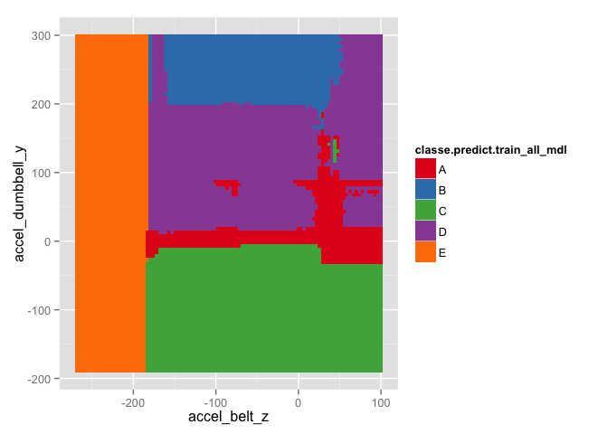

````r
#```{r inspect_test_predictions_2}
myplot_predict <- function(x, y) {
    png(filename=paste0("test_df_scatter_", x, "_", y, ".png"))
    #print(ggplot(test_plot_df, aes_string(x=feats_top_importance_lst[1],
    #                                      y=feats_top_importance_lst[2])) +
    print(ggplot(test_plot_df, aes_string(x=x, y=y)) +
            geom_point(aes_string(color=response_varname,
                                  shape="shape_error"), position="jitter") +
            scale_color_brewer(type="qual", palette="Set1") +
            scale_shape_identity(guide="legend", name="prediction"
                                 , labels=c("correct",
                                            "ignore_1", "ignore_2", "ignore_3",
                                            "error")
                                 ) +
            facet_wrap(reformulate(response_error_varname)))
    dev.off()
}
#myplot_predict(x="accel_belt_z", y="accel_dumbbell_y")

myplot_predict_tile <- function(x, y) {
    test_medians_df <- mycompute_medians_df(test_df[ , feats_df$feature], keep.names=TRUE)

    #x <- "accel_belt_z"; y <- "accel_dumbbell_y"
    decbndry_grid <- expand.grid(x=seq(min(test_df[ ,x]), max(test_df[ ,x]), length=100),
                                 y=seq(min(test_df[ ,y]), max(test_df[ ,y]), length=100))
    test_decbndry_df <- test_medians_df
    test_decbndry_df[2:nrow(decbndry_grid), ] <- test_decbndry_df[1, ]
    test_decbndry_df[, x] <- decbndry_grid$x
    test_decbndry_df[, y] <- decbndry_grid$y
    test_decbndry_df[, response_predict_varname] <- predict(train_all_mdl, test_decbndry_df)

    print(ggplot(test_decbndry_df, aes_string(x=x, y=y)) +
              geom_tile(aes_string(fill=response_predict_varname)) +
              scale_fill_brewer(type="qual", palette="Set1"))

    png(filename=paste0("test_decbndry_", x, "_", y, ".png"), width=960, height=960)
    print(ggplot(test_decbndry_df, aes_string(x=x, y=y)) +
              geom_tile(aes_string(fill=response_predict_varname), alpha=0.5) +
              scale_fill_brewer(type="qual", palette="Set1") +
              geom_point(data=test_plot_df,
                         mapping=aes_string(color=response_varname,
                                            shape="shape_error"), position="jitter") +
              scale_color_brewer(type="qual", palette="Set1") +
              scale_shape_identity(guide="legend", name="prediction",
                                   labels=c("correct",
                                            "ignore_1", "ignore_2", "ignore_3",
                                            "error")) +
              facet_wrap(reformulate(response_error_varname)))
    dev.off()
}
myplot_predict_tile(x="accel_belt_z", y="accel_dumbbell_y")
````

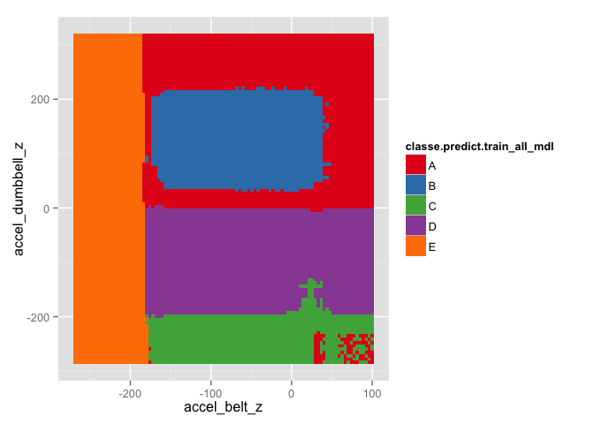

```r
myplot_predict_tile(x="accel_belt_z", y="accel_dumbbell_z")
```

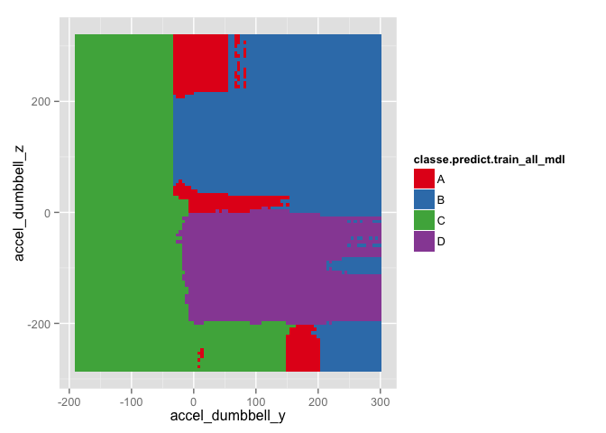

```r
myplot_predict_tile(x="accel_dumbbell_y", y="accel_dumbbell_z")
```

````r
#```{r inspect_test_predictions_3}
#myplot_predict(x="accel_belt_z", y="accel_dumbbell_z")

script_df <- rbind(script_df,
                   data.frame(chunk_label="fit_all_obs",
                              chunk_step_major=max(script_df$chunk_step_major)+1, chunk_step_minor=0))
````

#### Step `8`: fit all obs

```r
par_row <- par_grid[1, ]; par_row$mdl_name <- 'entity_all'; par_row$p_obs <- 1.0;
print(par_row)
```

```
##     mdl_name num_feats p_obs preProcess sampling_method n_resample mtry
## 1 entity_all        25     1       NULL              cv         10    3
```

```r
attach(mytrain_model(par_row, fit_df=entity_df))
entity_all_mdl <- fit_mdl;
detach(grep("^mytrain_model", search(), value=TRUE), character.only=TRUE)

print(entity_all_mdl)
```

```
## Random Forest
##
## 19617 samples
##    25 predictor
##     5 classes: 'A', 'B', 'C', 'D', 'E'
##
## No pre-processing
## Resampling: Cross-Validated (10 fold)
##
## Summary of sample sizes: 17656, 17656, 17655, 17655, 17655, 17654, ...
##
## Resampling results
##
##   Accuracy  Kappa  Accuracy SD  Kappa SD
##   0.986     0.983  0.00287      0.00363
##
## Tuning parameter 'mtry' was held constant at a value of 3
##
```

```r
print(entity_all_mdl$finalModel)
```

```
##
## Call:
##  randomForest(x = x, y = y, mtry = param$mtry)
##                Type of random forest: classification
##                      Number of trees: 500
## No. of variables tried at each split: 3
##
##         OOB estimate of  error rate: 1.21%
## Confusion matrix:
##      A    B    C    D    E class.error
## A 5539    4   13   22    1 0.007169744
## B   24 3748   21    1    2 0.012644889
## C    4   21 3384   12    0 0.010815551
## D   13    1   75 3122    4 0.028926905
## E    0    1    7   11 3587 0.005268996
```

```r
#print(confusionMatrix(test_df[, response_varname],
#                      predict(train_all_mdl, newdata=test_df)))
feats_df <- mymerge_varimp(feats_df, entity_all_mdl, "entity_all_mdl")
```

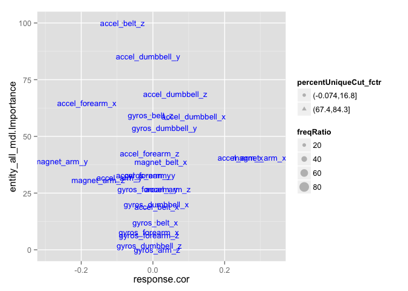

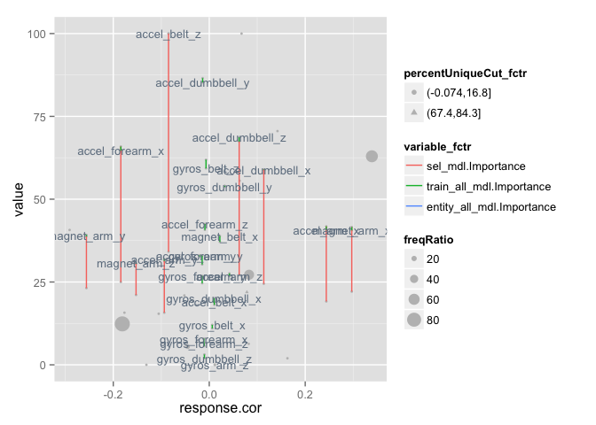

```r
feats_tmp_df <- orderBy(~ - response.cor.abs + entity_all_mdl.Importance,
                         data=feats_df)
feats_plot_df <- melt(feats_tmp_df, measure.vars=grep(".Importance", names(feats_df), value=TRUE))
feats_plot_df$variable_fctr <- factor(feats_plot_df$variable,
                                      levels=c("sel_mdl.Importance",
                                               "train_all_mdl.Importance",
                                               "entity_all_mdl.Importance"))
feats_plot_df <- mutate(feats_plot_df,
                        feature_tmp = ifelse((variable == "entity_all_mdl.Importance"), feature, ""))
print(ggplot(feats_plot_df, aes(x=response.cor, y=value, group=feature)) +
          geom_point(aes(size=freqRatio, shape=percentUniqueCut_fctr), color="grey") +
          geom_line(aes(color=variable_fctr)) +
          geom_text(aes(label=feature_tmp), color="slategrey", size=3.5))
```

```r
script_df <- rbind(script_df,
                   data.frame(chunk_label="predict_newdata",
                              chunk_step_major=max(script_df$chunk_step_major)+1, chunk_step_minor=0))
```

There’s some re-ordering of variable importances (e.g. accel_belt_z replaces roll_belt as the most important feature).

#### Step `9`: predict_newdata

```r
response_predict_varname <- paste0(response_varname, ".predict.", "entity_all_mdl")
predict_df[, response_predict_varname] <- predict(entity_all_mdl, predict_df)
print(predict_df[, c("X", "user_name", response_predict_varname)])
```

```
##     X user_name classe.predict.entity_all_mdl
## 1   1     pedro                             B
## 2   2    jeremy                             A
## 3   3    jeremy                             B
## 4   4    adelmo                             A
## 5   5    eurico                             A
## 6   6    jeremy                             E
## 7   7    jeremy                             D
## 8   8    jeremy                             B
## 9   9  carlitos                             A
## 10 10   charles                             A
## 11 11  carlitos                             B
## 12 12    jeremy                             C
## 13 13    eurico                             B
## 14 14    jeremy                             A
## 15 15    jeremy                             E
## 16 16    eurico                             E
## 17 17     pedro                             A
## 18 18  carlitos                             B
## 19 19     pedro                             B
## 20 20    eurico                             B
```

```r
script_df <- rbind(script_df,
                   data.frame(chunk_label="export_predictions",
                              chunk_step_major=max(script_df$chunk_step_major)+1, chunk_step_minor=0))
```

#### Step `10`: export_prediction

```r
export_pml_files <- function(x, dir_name) {

    if (!file.exists(paste0("./export"))) dir.create("export")
    if (!file.exists(paste0("./export/", dir_name)))
        dir.create(paste0("./export/", dir_name))

    for (i in 1:length(x)) {
        filename <- paste0("./export/", dir_name, "/problem_id_", i, ".txt")
        write.table(x[i], file=filename, quote=FALSE,
                    row.names=FALSE, col.names=FALSE)
    }
}
#export_pml_files(predict_df[, response_predict_varname], "entity_all_mdl")
```